# M504 AI and Applications

# **Predicting Car Prices Based on Vehicle Features Using Data Analytics**

Module code: M504

Module Name: AI and Applications

Name- Devansh Gupta

Student ID- GH1046737

# Business Context

The customer of this project is a car dealership/vehicle distribution company that should have a more precise idea of the car market to be able to make strategic choices. There are various types of vehicles that the company sells and it has to make decisions regarding the kind of vehicles to be stocked, the kind of price range to concentrate on and the kind of brands to concentrate on. The competition in the market is intense, preferences of customers evolve, and pricing can influence the profitability (Moraga-Gonzalez et al., 2023). The management thus needs a thorough analysis of the data that will show the relationship between the vehicle features, the brand reputation, fuel efficiency, engine performance, and the size of the vehicle to price and market popularity.

The company is exposed to a decision issue, which deals with market positioning and selection of the product. There are vehicles that make high profit but they sell low and there are those which sell high but make lower profit per unit. The management should thus be aware of the correlation between price, popularity, performance, and car features (Fatima et al., 2024). The data contains details regarding vehicle characteristics, brand popularity and price that can be examined to determine customer preference tendencies and market structure. Knowledge of these trends assists the company in determining the populations to target luxury cars, middle and low-end cars.

This analysis aims at converting vehicle data into business intelligence that enables strategic planning. The analysis will aim to find out the number of vehicle segments dominating the market, features that affect the price, positioning of brands in various segments of the market, and the market opportunities. This study will be used to enhance the company in terms of inventory planning, price determination, product positioning and market targeting. The last objective is to enable data-driven decision making and lessen business risk through application of market evidence rather than assumptions.

# Dataset Characteristics

The data to be analyzed in this paper includes the data on various vehicles and their technical and other market-oriented aspects. All those rows signify the model of a vehicle and all columns define the feature of a vehicle which is brand, engine, fuel efficiency, vehicle size, vehicle style, popularity, and the manufacturer suggested retail price (MSRP). The data will contain both continuous and nominal variables, which will provide an opportunity to examine the price trends, market dynamics, features of performance, and positioning in the market. Some of the numerical variables are engine horsepower, engine cylinders, fuel efficiency, popularity, year, and price. Categorical variables encompass vehicle brand, fuel type, transmission type, vehicle size, vehicle style and drive wheels.

The initial dataset had 11,914 records and 16 variables. The sizes of the data were decreased after cleaning and elimination of redundant data. More features were developed in the process of feature engineering to enhance analysis. These new features are; car age, average fuel efficiency, horsepower per cylinder, door category, and popularity category. These artificial characteristics are useful in characterizing vehicle performance, performance, depreciation as well as market demand. The data is thus a powerful foundation to segment the market, price, brand positioning and identification of the market opportunity.

The analysis analysis in the future aims to involve the use of exploratory data analysis to provide answers to the business questions regarding the market structure, pricing behaviour, customer preferences and brand positioning. The second phase of the project is the vehicle size distribution, price distribution, vehicle style pricing, fuel efficiency and performance relationship, market opportunity across vehicle styles and brand positioning in various market segments and price versus popularity relationship. All the analysis steps will answer a given business question and give information that will enable decision making within the automobile company.

**Source: https://www.kaggle.com/datasets/CooperUnion/cardataset**

```python
import pandas as pd
import numpy as np

# Load dataset
df = pd.read_csv("data.csv")

# Display first rows
df.head()
```

|  | Make | Model | Year | Engine Fuel Type | Engine HP | Engine Cylinders | Transmission Type | Driven_Wheels | Number of Doors | Market Category | Vehicle Size | Vehicle Style | highway MPG | city mpg | Popularity | MSRP |
| --- | --- | --- | --- | --- | --- | --- | --- | --- | --- | --- | --- | --- | --- | --- | --- | --- |
| 0 | BMW | 1 Series M | 2011 | premium unleaded (required) | 335.0 | 6.0 | MANUAL | rear wheel drive | 2.0 | Factory Tuner,Luxury,High-Performance | Compact | Coupe | 26 | 19 | 3916 | 46135 |
| 1 | BMW | 1 Series | 2011 | premium unleaded (required) | 300.0 | 6.0 | MANUAL | rear wheel drive | 2.0 | Luxury,Performance | Compact | Convertible | 28 | 19 | 3916 | 40650 |
| 2 | BMW | 1 Series | 2011 | premium unleaded (required) | 300.0 | 6.0 | MANUAL | rear wheel drive | 2.0 | Luxury,High-Performance | Compact | Coupe | 28 | 20 | 3916 | 36350 |
| 3 | BMW | 1 Series | 2011 | premium unleaded (required) | 230.0 | 6.0 | MANUAL | rear wheel drive | 2.0 | Luxury,Performance | Compact | Coupe | 28 | 18 | 3916 | 29450 |
| 4 | BMW | 1 Series | 2011 | premium unleaded (required) | 230.0 | 6.0 | MANUAL | rear wheel drive | 2.0 | Luxury | Compact | Convertible | 28 | 18 | 3916 | 34500 |

```python
# Shape of dataset
print("Dataset Shape:", df.shape)
```

```
Dataset Shape: (11914, 16)
```

```python
# Dataset info
df.info()
```

```
<class 'pandas.core.frame.DataFrame'>
RangeIndex: 11914 entries, 0 to 11913
Data columns (total 16 columns):
 #   Column             Non-Null Count  Dtype
---  ------             --------------  -----
 0   Make               11914 non-null  object
 1   Model              11914 non-null  object
 2   Year               11914 non-null  int64
 3   Engine Fuel Type   11911 non-null  object
 4   Engine HP          11845 non-null  float64
 5   Engine Cylinders   11884 non-null  float64
 6   Transmission Type  11914 non-null  object
 7   Driven_Wheels      11914 non-null  object
 8   Number of Doors    11908 non-null  float64
 9   Market Category    8172 non-null   object
 10  Vehicle Size       11914 non-null  object
 11  Vehicle Style      11914 non-null  object
 12  highway MPG        11914 non-null  int64
 13  city mpg           11914 non-null  int64
 14  Popularity         11914 non-null  int64
 15  MSRP               11914 non-null  int64
dtypes: float64(3), int64(5), object(8)
memory usage: 1.5+ MB
```

```python
# Statistical summary
df.describe()
```

|  | Year | Engine HP | Engine Cylinders | Number of Doors | highway MPG | city mpg | Popularity | MSRP |
| --- | --- | --- | --- | --- | --- | --- | --- | --- |
| count | 11914.000000 | 11845.00000 | 11884.000000 | 11908.000000 | 11914.000000 | 11914.000000 | 11914.000000 | 1.191400e+04 |
| mean | 2010.384338 | 249.38607 | 5.628829 | 3.436093 | 26.637485 | 19.733255 | 1554.911197 | 4.059474e+04 |
| std | 7.579740 | 109.19187 | 1.780559 | 0.881315 | 8.863001 | 8.987798 | 1441.855347 | 6.010910e+04 |
| min | 1990.000000 | 55.00000 | 0.000000 | 2.000000 | 12.000000 | 7.000000 | 2.000000 | 2.000000e+03 |
| 25% | 2007.000000 | 170.00000 | 4.000000 | 2.000000 | 22.000000 | 16.000000 | 549.000000 | 2.100000e+04 |
| 50% | 2015.000000 | 227.00000 | 6.000000 | 4.000000 | 26.000000 | 18.000000 | 1385.000000 | 2.999500e+04 |
| 75% | 2016.000000 | 300.00000 | 6.000000 | 4.000000 | 30.000000 | 22.000000 | 2009.000000 | 4.223125e+04 |
| max | 2017.000000 | 1001.00000 | 16.000000 | 4.000000 | 354.000000 | 137.000000 | 5657.000000 | 2.065902e+06 |

```python
df.describe(include='object')
```

|  | Make | Model | Engine Fuel Type | Transmission Type | Driven_Wheels | Market Category | Vehicle Size | Vehicle Style |
| --- | --- | --- | --- | --- | --- | --- | --- | --- |
| count | 11914 | 11914 | 11911 | 11914 | 11914 | 8172 | 11914 | 11914 |
| unique | 48 | 915 | 10 | 5 | 4 | 71 | 3 | 16 |
| top | Chevrolet | Silverado 1500 | regular unleaded | AUTOMATIC | front wheel drive | Crossover | Compact | Sedan |
| freq | 1123 | 156 | 7172 | 8266 | 4787 | 1110 | 4764 | 3048 |

```python
# Missing values
missing_values = df.isnull().sum()

# Percentage missing
missing_percent = (missing_values / len(df)) * 100

missing_table = pd.DataFrame({
    'Missing Values': missing_values,
    'Percentage': missing_percent
})

print(missing_table)
```

```
                   Missing Values  Percentage
Make                            0    0.000000
Model                           0    0.000000
Year                            0    0.000000
Engine Fuel Type                3    0.025180
Engine HP                      69    0.579151
Engine Cylinders               30    0.251805
Transmission Type               0    0.000000
Driven_Wheels                   0    0.000000
Number of Doors                 6    0.050361
Market Category              3742   31.408427
Vehicle Size                    0    0.000000
Vehicle Style                   0    0.000000
highway MPG                     0    0.000000
city mpg                        0    0.000000
Popularity                      0    0.000000
MSRP                            0    0.000000
```

```python
# Duplicate rows
duplicates = df.duplicated().sum()
print("Number of duplicate rows:", duplicates)
```

```
Number of duplicate rows: 715
```

# Data Quality Issues

A number of data quality problems were defined in the process of first exploration of the dataset. Such problems were missing values in various variables, duplicates, and large numbers of unique categories in variables. Such issues might have implications on the dependability of the statistical analysis, market segmentation and price analysis and hence data cleaning was necessary to proceed with the analysis.

There were missing values in some of the variables but the most notable problem was the Market Category variable which contained 3,742 missing values, which is very close to 31.4 percent of the dataset. This was a huge percentage and might influence category based analysis and market segmentation. The other variables that had missing values were Engine HP (69 missing values), Engine Cylinders (30 missing values), Number of Doors (6 missing values), and Engine Fuel Type (3 missing values). The level of missing values of these variables was not very high, but missing numerical values may influence average calculations, correlations, and price analysis and missing categorical values may influence grouping and category comparison.

The next critical data quality problem was that there were 715 duplicate rows in the data. Reproduction of records may corrupt statistical summaries like mean price, popularity distribution, and frequency counts. Without deleting duplicates, that would give a higher representation of some of the vehicles in the analysis and may give us false business information. Thus, duplicate records had to be eliminated prior to analysis.

The Model column was also determined as a possible problem since it had a very high number of unique values (915 unique models). This variable would not yield itself to grouped analysis and would be an unnecessary complication to the market analysis of the dataset. Hence, it was eliminated in the process of cleaning of data.

```python
# Remove duplicates
df = df.drop_duplicates()

# Fill missing values
df['Engine HP'].fillna(df['Engine HP'].median(), inplace=True)
df['Engine Cylinders'].fillna(df['Engine Cylinders'].median(), inplace=True)
df['Number of Doors'].fillna(df['Number of Doors'].mode()[0], inplace=True)
df['Engine Fuel Type'].fillna(df['Engine Fuel Type'].mode()[0], inplace=True)

# Market Category has many missing values
df['Market Category'].fillna('Unknown', inplace=True)

# Convert Doors and Cylinders to integer
df['Number of Doors'] = df['Number of Doors'].astype(int)
df['Engine Cylinders'] = df['Engine Cylinders'].astype(int)

# Drop Model column (too many unique values)
df = df.drop('Model', axis=1)

print(df.shape)
```

```
(11199, 15)
```

[output not shown]

# Data Cleaning and Pre-Processing Steps

A number of activities on data cleaning and preprocessing were conducted to make the dataset ready to analysis. It needed such steps to enhance the quality of the data, maintain its consistency, and to generate more variables which would be used in business analysis and in the market segmentation.

The initial process was to determine and eliminate duplicated records. The dataset had 715 duplicate records that may distort statistical analysis and interpretations and give wrong findings as some records of vehicles may be included in the dataset more than once. These were the duplicate records which were eliminated in order to have one record in every vehicle.

The second step was to deal with missing values. Both numeric and nominal variables had missing values. The empty values of the Engine HP and Engine Cylinders were filled using the median since the median is less sensitive to extreme values and it gives a more resilient estimate of numerical data. The mode was used to fill in the number of Doors and Engine Fuel Type since the variables are categorical or discrete by nature. The missing values of the Market Category variable were very numerous and this is why instead of deleting the rows, they were filled by the category of the unknown and this maintained the size of the dataset but still showed the information of the missing category.

Data types were realigned after processing values of missing data. Number of Doors and Engine Cylinders were transformed in integers due to the nature of the variables namely Number of Doors and Engine Cylinders; they are discrete variables and not continuous. The Model column was dropped since it had a very high number of distinct values and was not adding much value to the analysis of the market levels. The elimination of this column made the data simpler and minimized the complexity.

The final shape of the data is 11199 rows and 15 columns

```python
# Feature Engineering

# Car Age
df['Car Age'] = 2024 - df['Year']

# Average MPG
df['Avg MPG'] = (df['city mpg'] + df['highway MPG']) / 2

# HP per Cylinder
df['HP per Cylinder'] = df['Engine HP'] / df['Engine Cylinders']

# Doors Category
df['Doors Category'] = df['Number of Doors'].apply(
    lambda x: 'Two' if x == 2 else 'Four'
)

# Popularity Category
df['Popularity Category'] = pd.cut(
    df['Popularity'],
    bins=[0, 1000, 3000, 6000],
    labels=['Low', 'Medium', 'High']
)
```

# Feature Engineering

The feature engineering was done to generate new variables that might have a better ability to capture vehicle characteristics and market behaviour as they are not easily available in the original dataset. These initial variables gave raw technical data like engine horsepower, fuel efficiency and year but the variables failed to tell directly about other concepts like the age of various vehicles, the overall fuel efficiency of the vehicles, engine efficiency of the vehicle and market popularity segments. Thus, there were new variables developed and to give the dataset more meaning in terms of business analysis and market segmentation.

The variable of the car age was formulated out of the year variable to indicate the depreciation of the vehicles and their lifecycle. This variable is beneficial to comprehend the relation of older vehicle to price and positioning in the market. The average MPG variable was developed by combining the city and highway fuel efficiency to develop one variable of fuel efficiency later on added in the bubble chart that represented the relationship between fuel efficiency, engine power and price. The Horsepower per Cylinder variable was designed to reflect the efficiency of the engine and not merely on the size of the engine and it aids in explaining the efficiency of the performance of various cars.

The Doors Category It ranked the vehicles as two doors and four-doors and that has made it easy to analyze the type of vehicles and customer preferences. The Popularity Category variable reflected the vehicles into the low, middle, and high popular segments and it was used to segment the market and to learn the distribution of the demand among various vehicles and brands.

# Exploratory Data Analysis

Exploratory data analysis in this study is aimed at stepping further beyond describing the features of the vehicles but rather come up with orderly understanding of the automobile market as concerned with price formation, segmentation of the market, patterns of consumer preference, and competitive positioning of the brands. The analysis of the issue tries to determine the effect of technical specifications of the engine power, fuel consumption, car size and the drive system on the prices of the cars and the connection between the prices and the popularity and demand. This enables the analysis to draw a line between the high-performance vehicles, economy vehicles and mid-range vehicles since these are the strategic market segments.

The other aim of the exploratory analysis is to find the relationship between demand and pricing, specifically whether high priced cars are more popular or it is dominated with low priced but high demand cars. This is used to get some insight of whether the market is of luxury based model or volume based model. The distribution of the vehicle styles and sizes across price groups is also analyzed to determine the interest of the vehicle types that create the most market and those that operate in niche markets.

The perspectives created due to this analysis assist the client to learn market structure, demand concentration, pricing agents, and brand positioning strategies. The following insights can be applied to find the most profitable vehicle segments, find the best competitive pricing strategies, what vehicle features add the most value and what are the possible gaps in the market where the demand is high and competition maybe low. Hence the exploratory analysis is not only descriptive, but strategic because it facilitates decision making regarding product positioning, inventory planning, pricing approach as well as making a decision regarding market entry.

```python
import seaborn as sns
import matplotlib.pyplot as plt

sns.set_style("whitegrid")
sns.set_palette("Set2")
plt.rcParams['figure.figsize'] = (10,6)
```

# 1. Market Distribution by Vehicle Size

**Question: Which vehicle size category dominates the automobile market, and what does this indicate about customer demand concentration across vehicle segments?**

Knowing the size of vehicles that are dominating the market will assist the company in deciding where to focus inventory and production needs because they are the vehicles that are in high demand in the market.

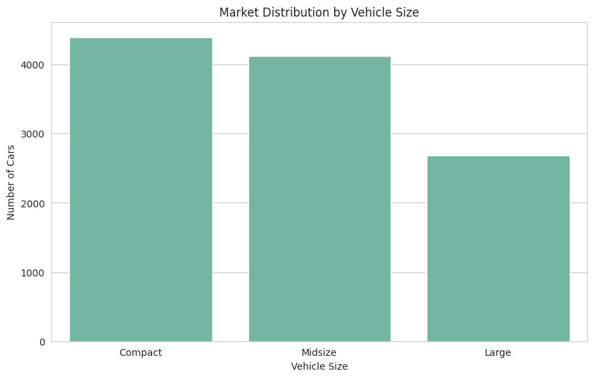

```python
# Market Distribution by Vehicle Size
sns.countplot(x='Vehicle Size', data=df)
plt.title('Market Distribution by Vehicle Size')
plt.xlabel('Vehicle Size')
plt.ylabel('Number of Cars')
plt.show()
```

**Insights**

Compact vehicles account for roughly 4,400 vehicles, making them the largest segment.

Midsize vehicles account for around 4,100 vehicles, slightly lower than compact vehicles.

Large vehicles account for approximately 2,700 vehicles, making them the smallest segment.

Compact and midsize vehicles together represent around 75% of the total market, indicating demand concentration in smaller vehicles.

Large vehicles represent a smaller but potentially higher price segment.

# 2. Price Distribution of Cars

**Question: How are car prices distributed across the market, and which price segment dominates the automobile industry?**

Price distribution assists in determining whether the market is characterized by affordable cars, middle-end cars, or luxurious cars, which affect pricing and product positioning.

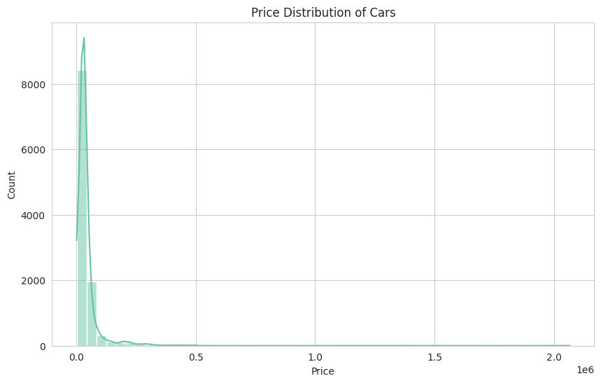

```python
# Price Distribution
sns.histplot(df['MSRP'], bins=50, kde=True)
plt.title('Price Distribution of Cars')
plt.xlabel('Price')
plt.show()
```

**Insights**

The majority of vehicles are priced below $50,000, indicating a strong budget and mid-range market.

Very few vehicles exceed $150,000, showing that luxury vehicles represent a small portion of the market.

The distribution is heavily right-skewed, meaning a small number of very expensive vehicles exist.

The median price is around $30,000, indicating the mid-range market dominates.

The maximum price exceeds $2,000,000, representing ultra-luxury vehicles.

# 3. Vehicle Style vs Price

**Question: How does vehicle style influence pricing, and which vehicle styles operate in higher price segments?**

Price variations apply to various market segments but there are distinct styles of vehicles, thus the knowledge about them is useful in product positioning.

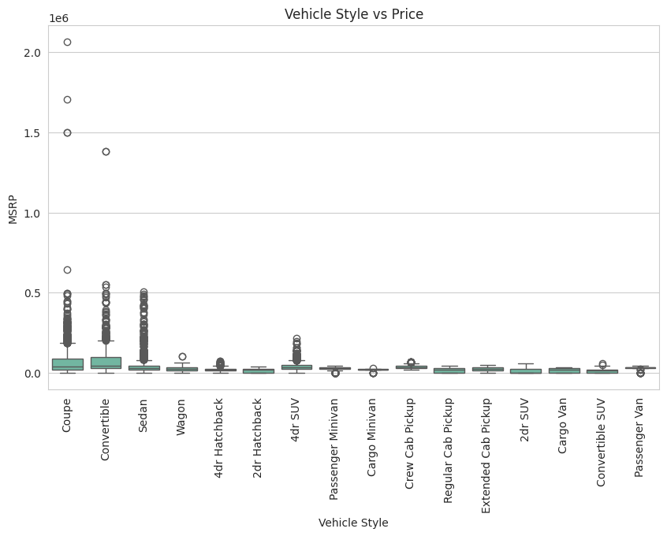

```python
# Vehicle Style vs Price
sns.boxplot(x='Vehicle Style', y='MSRP', data=df)
plt.xticks(rotation=90)
plt.title('Vehicle Style vs Price')
plt.show()
```

**Insights**

Convertibles and coupes show prices exceeding $80,000 on average in some cases.

Sedans and hatchbacks mostly fall within $20,000 to $40,000 price range.

SUVs and pickup trucks fall in $30,000 to $60,000 range.

Cargo vans and passenger vans appear in mid-price segments.

Luxury vehicle styles are fewer but significantly higher priced.

# 4. Fuel Efficiency vs Price vs Engine Power

**Question: What relationship exists between fuel efficiency, engine power, and vehicle price, and does a trade-off exist between performance and fuel efficiency?**

Knowledge of this relationship assists companies in developing vehicles that would be performance, price and fuel efficient.

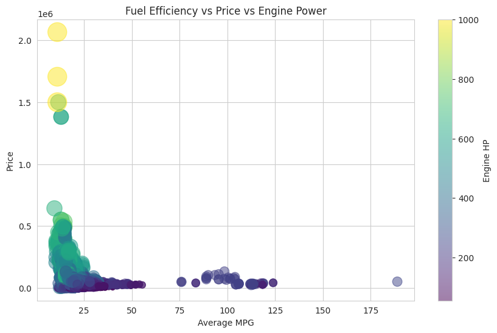

```python
# Fuel Efficiency vs Price vs Engine Power
plt.scatter(df['Avg MPG'], df['MSRP'],
            s=df['Engine HP']/2,
            alpha=0.5,
            c=df['Engine HP'],
            cmap='viridis')

plt.colorbar(label='Engine HP')
plt.xlabel('Average MPG')
plt.ylabel('Price')
plt.title('Fuel Efficiency vs Price vs Engine Power')
plt.show()
```

**Insights**

Vehicles with engine power above 400 HP tend to have prices above $60,000.

Low MPG vehicles (below 20 MPG) often correspond to high engine power vehicles.

High performance vehicles tend to have lower fuel efficiency.

The graph shows a clear trade-off between performance and fuel efficiency.

# 5. Market Opportunity Analysis (Popularity vs Price)

**Question: Which vehicle styles represent the best market opportunity based on high popularity and moderate price levels?**

Popularity and moderate price usually prove to be an indicator of high sales and a high-revenue value.

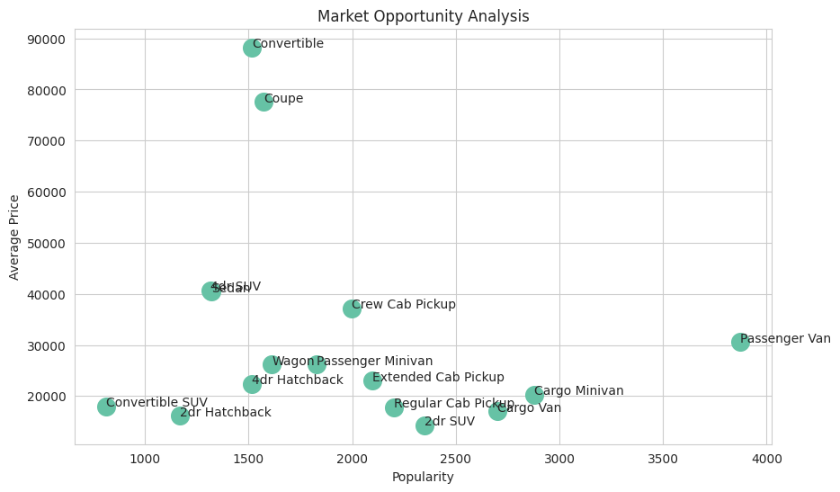

```python
style_analysis = df.groupby('Vehicle Style').agg({
    'MSRP':'mean',
    'Popularity':'mean'
}).reset_index()

plt.scatter(style_analysis['Popularity'], style_analysis['MSRP'], s=200)

for i in range(len(style_analysis)):
    plt.text(style_analysis['Popularity'][i],
             style_analysis['MSRP'][i],
             style_analysis['Vehicle Style'][i])

plt.xlabel('Popularity')
plt.ylabel('Average Price')
plt.title('Market Opportunity Analysis')
plt.show()
```

**Insights**

Passenger vans show popularity close to 3,800, with average price around $30,000.

Sedans and SUVs show popularity between 1,300 and 1,500 with prices around $40,000.

Hatchbacks show popularity around 1,200–1,600 with prices around $20,000–$25,000.

Convertibles have high prices (~$85,000) but lower popularity.

The best market opportunity appears in mid-price segments with popularity above 1,500.

# 6. Brand Positioning – Top Popular Brands

**Question: How are the most popular automobile brands positioned in terms of price and popularity, and which brands dominate different market segments?**

Brand positioning is good in comprehending competition, price strategy and market segmentation.

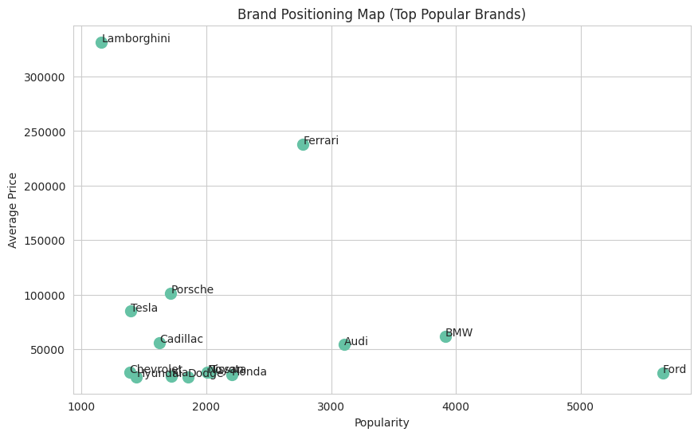

```python
brand_analysis = df.groupby('Make').agg({
    'MSRP':'mean',
    'Popularity':'mean'
}).reset_index()

# Select top brands by popularity
top_brands = brand_analysis.sort_values('Popularity', ascending=False).head(15)

plt.figure(figsize=(10,6))
plt.scatter(top_brands['Popularity'], top_brands['MSRP'], s=100)

for i in range(len(top_brands)):
    plt.text(top_brands['Popularity'].iloc[i],
             top_brands['MSRP'].iloc[i],
             top_brands['Make'].iloc[i])

plt.xlabel('Popularity')
plt.ylabel('Average Price')
plt.title('Brand Positioning Map (Top Popular Brands)')
plt.show()
```

**Insights**

Ford shows the highest popularity at around 5,500, with average price around $30,000.

BMW and Audi operate in premium segments with prices around $60,000 and popularity above 3,000.

Tesla and Porsche operate in mid-to-premium segments with prices between $80,000 and $100,000.

Lamborghini and Ferrari show very high prices above $200,000 but lower popularity.

Mass-market brands dominate popularity, while luxury brands dominate price.

# 7. Brand Positioning by Market Segment

**Question: How are automobile brands distributed across budget, mid-range, and luxury segments, and which segment contains the most competitors?**

Market segmentation will assist firms in determining the position they should place their products and also determine the level of competition.

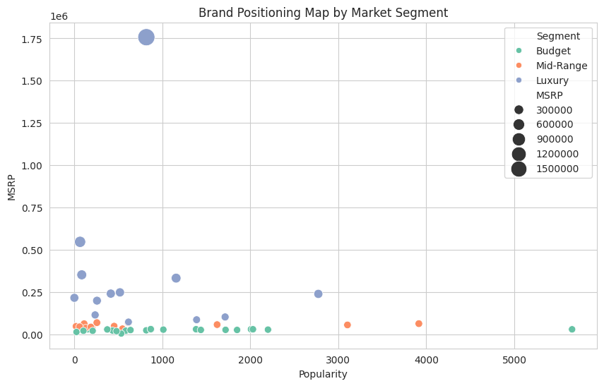

```python
brand_analysis['Segment'] = pd.cut(
    brand_analysis['MSRP'],
    bins=[0, 30000, 70000, 2000000],
    labels=['Budget', 'Mid-Range', 'Luxury']
)

plt.figure(figsize=(10,6))
sns.scatterplot(data=brand_analysis,
                x='Popularity',
                y='MSRP',
                hue='Segment',
                size='MSRP',
                sizes=(50,300))

plt.title('Brand Positioning Map by Market Segment')
plt.show()
```

**Insights**

Mid-range segment between $30,000 and $70,000 contains several premium brands.

Luxury segment above $70,000 contains fewer brands but very high prices.

Budget segment appears most competitive due to many brands. Luxury segment is smaller but high profit per vehicle.

# 8. Engine Power by Vehicle Size

**Question: How does engine power vary across vehicle sizes, and how does vehicle size influence performance characteristics?**

Engine power influences the price and fuel consumption, as well as positioning of a vehicle in the market.

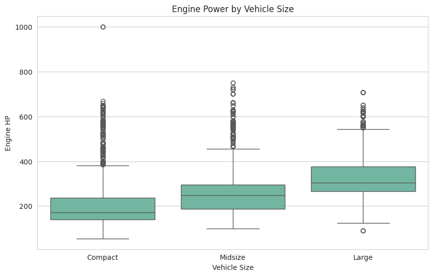

```python
sns.boxplot(x='Vehicle Size', y='Engine HP', data=df)
plt.title('Engine Power by Vehicle Size')
plt.show()
```

**Insights**

Compact vehicles typically have engine power between 120–220 HP.

Midsize vehicles range between 180–300 HP.

Large vehicles often range between 250–400 HP.

Some large vehicles exceed 600 HP, indicating performance vehicles.

Engine power increases with vehicle size.

# 9. Price vs Popularity

**Question: Is there a relationship between vehicle price and popularity, and does higher price lead to higher demand?**

This assists in identifying the luxury vehicles and cheap vehicles in the market.

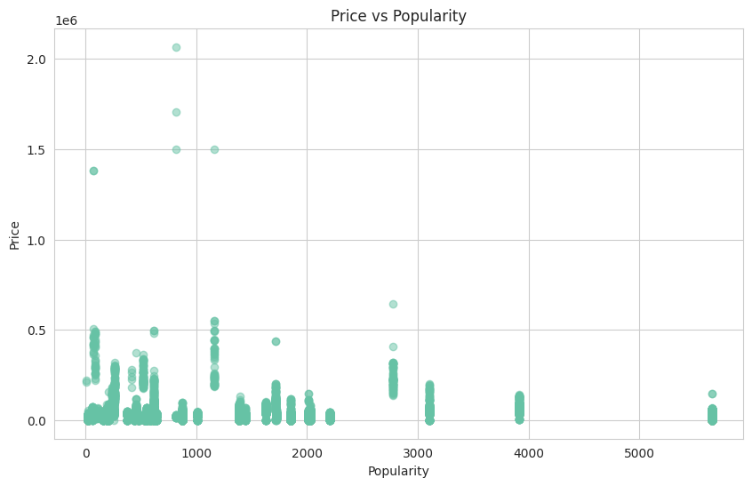

```python
plt.scatter(df['Popularity'], df['MSRP'], alpha=0.5)
plt.xlabel('Popularity')
plt.ylabel('Price')
plt.title('Price vs Popularity')
plt.show()
```

**Insights**

Most popular vehicles are priced below $40,000.

Some mid-price vehicles ($30,000–$60,000) show moderate popularity.

Market demand is concentrated in affordable vehicle segments.

# Critical Analysis, Interpretations, Limitations, Business Recommendations and Conclusion

The car data analysis demonstrates that there are a number of noteworthy tendencies pertaining to market structure, price behaviour, segmentation and positioning. The market distribution analysis reveals that there is a greater number of compact and midsize cars than the large and luxury cars combined, which means that the automobile market is characterized by practical, affordable cars, rather than large or luxury car. The analysis of price distribution is heavily right skewed with majority of cars being lower than the mid-range prices with only a few vehicles being spread in price ranges very high. This implies that the car business is more of a quantity market than a luxury business. The connection between engine power, fuel consumption, and the price demonstrate a distinct trade-off between the performance and efficiency implying that the manufacturers have to find a balance between the two aspects based on the market segment. The brand positioning analysis also reveals that it is possible to classify brands into mass-market, premium, and luxury markets, where mass-market brands are the most popular and luxury ones are very price-sensitive and not demand-sensitive.

However, the dataset and analysis have a number of limitations. Actual sales volume, profit margins, customer demographics and cost of production are not provided in the data, thus restricting the capability of drawing direct conclusions on profitability. Demand is estimated using popularity which is a proxy of brand recognition and not necessarily sales performance. There is also a lack of vehicles of various years in the dataset, and the inflation or the change in the prices with time have not been factored, and this could influence the price comparison. Also, no geographic market information, level of income of customers or competitors strategies is provided as part of the data and this is a major factor in the actual automobile market analysis. That is why the analysis is helpful to obtain the insights into the market, but it must be regarded as indicative instead of definitive.

# References

Fatima, A., Rasheed, A., Khan, A. and Atif, M., 2024. Improving car price predictions by identifying key features. *Spectrum of engineering sciences*, pp.148-172.

Moraga-González, J.L., Sándor, Z. and Wildenbeest, M.R., 2023. Consumer search and prices in the automobile market. The Review of Economic Studies, 90(3), pp.1394-1440.